[figure not shown]

# Rock The Upvote:

## Predicting the Success of a Reddit Post

Neehar Peri, Wilson Orlando

## Introduction

Ever heard of Reddit? Maybe you already have; it's the [6th most visited website in the U.S.](https://www.alexa.com/topsites/countries/US) If this is your first time hearing about it, Reddit is a "social news aggregation forum", which is the official way of saying it gathers content from all over the internet to display in one place. Users submit content to Reddit like links, text posts, and images, and that content gets liked ("upvoted") or disliked ("downvoted") by other users. Posts are grouped into user-created boards called "subreddits" focused on one topic- like [cute animals](https://www.reddit.com/r/aww/), [world news](https://www.reddit.com/r/worldnews/), or [Game of Thrones](https://www.reddit.com/r/gameofthrones/)- and the most upvoted posts across all subreddits are shown on the site's front page. You can read more about it [here](https://mashable.com/2012/06/06/reddit-for-beginners/).

With 330 million users and over 20 thousand daily submissions, it’s hard to predict which posts will get popular enough to hit the front page. If your predictions were good enough to craft viral Reddit posts, though, you could get your ideas out to those millions of users in a matter of hours. Many users don’t realize that Reddit can be- and is already being- manipulated to spread more than cute cats. [Large financial service companies use Reddit](https://www.forbes.com/sites/jaymcgregor/2017/02/20/reddit-is-being-manipulated-by-big-financial-services-companies/#109284f94c92) to boost their online image, and just this month the Reddit team claimed [leaked U.S.-U.K. trade documents posted on their site](https://time.com/5745917/reddit-uk-trade-documents-russia/) were part of a large-scale misinformation campaign originating from Russia. On top of getting your own upvotes, understanding what makes a Reddit post popular is critical for your informed online browsing.

Given the huge amount of data Reddit generates, it’s also an interesting problem for data science: based on existing Reddit posts, can we identify the most important features of a successful post and predict a post’s success before it’s submitted? In this tutorial, our goal is to download and tidy data from Reddit, perform some exploratory analysis to identify important features, then use machine learning models to predict a post’s upvote rating based on those features. For readers unfamiliar with Reddit, we hope our analysis will get you interested in the site and in some popular posts. For more experienced readers, we hope to give you some insight into how your favorite “social news aggregation forum” works, and show you how to get your own posts to the front page of the internet.

## Getting Started with the Data

We use Python 3 and some imported libraries, like [torch](https://pytorch.org/), [pandas](https://pandas.pydata.org/), [matplotlib](https://matplotlib.org/), [scikit-learn](https://scikit-learn.org/stable/), and more.

```python
from textblob import TextBlob
import torch
import torch.nn as nn
import torch.optim as optim
import pandas as pd
import matplotlib.pyplot as plt
import seaborn as sns
from sklearn.linear_model import Lasso, LogisticRegression
import sklearn.metrics as metrics
from sklearn.model_selection import train_test_split
from tqdm import tqdm
from pprint import pprint
import numpy as np
import praw
import pdb
import warnings
warnings.filterwarnings("ignore")
```

### Data Collection

To scrape data from Reddit, we'll be using [PRAW (the Python Reddit API Wrapper)](https://praw.readthedocs.io/en/latest/). For this analysis, we chose to pull data into two datasets:

1. Top Posts: The 1000 most upvoted posts in the last year
2. Controversial Posts: The 1000 most controversial posts in the last year

This gives us a good spread of recent posts that have been wildly successful and unsuccessful.

```python
# Establish connection using Reddit's API
clientID = 'VpVEXRwC5-nrbA'
clientSecret = 'XMql3JHOqhq2NatetFMFPkhBaCE'
userAgent = 'Reddit WebScraping'
reddit = praw.Reddit(client_id=clientID, client_secret=clientSecret, user_agent=userAgent)
```

```python
# Retrieve the top (most upvoted) 1k posts in the last year and add them to a Pandas dataframe
topPosts = []
subReddit = reddit.subreddit('all')
for post in tqdm(subReddit.top(time_filter = 'year', limit=1000), total=1000):
    topPosts.append([post.title, post.score, post.id, post.subreddit, post.url, post.num_comments, post.selftext, post.created_utc, post.author, post.is_self, post.over_18, post.spoiler, post.upvote_ratio])
topPosts = pd.DataFrame(topPosts,columns=['title', 'score', 'id', 'subreddit', 'url', 'num_comments', 'body', 'created', 'author', 'is_self', 'over_18', 'spoiler', 'upvote_ratio'])
topPosts.to_csv("top1KPosts.csv", index=False)

# Retrieve the most controversial (most downvoted) 1k posts in the last year and add them to a Pandas dataframe
controvertialPosts = []
subReddit = reddit.subreddit('all')
for post in tqdm(subReddit.controversial(time_filter = 'year', limit=1000), total=1000):
    controvertialPosts.append([post.title, post.score, post.id, post.subreddit, post.url, post.num_comments, post.selftext, post.created_utc, post.author, post.is_self, post.over_18, post.spoiler, post.upvote_ratio])
controvertialPosts = pd.DataFrame(controvertialPosts,columns=['title', 'score', 'id', 'subreddit', 'url', 'num_comments', 'body', 'created', 'author', 'is_self', 'over_18', 'spoiler', 'upvote_ratio'])
controvertialPosts.to_csv("controvertial1KPosts.csv", index=False)
```

```python
top1KPosts = pd.read_csv("top1kPosts.csv")
controversial1KPosts = pd.read_csv("controversial1kPosts.csv")
```

Next, let's take a look at some of the subreddits that have broken the top 1000 and controversial 1000 posts:

```python
#Top 10 List of subreddits that have broken top 1k
topSubReddit = top1KPosts.subreddit.unique()
topSubReddit[0:10]
```

```
array(['pics', 'gaming', 'AskReddit', 'Showerthoughts', 'news', 'memes',
       'funny', 'YouFellForItFool', 'aww', 'videos'], dtype=object)
```

```python
 #Top 10 subreddits that have broken most controversial 1k
controversialSubReddits = controversial1KPosts.subreddit.unique()
controversialSubReddits[0:10]
```

```
array(['motorcycles', 'unpopularopinion', 'IAmA', 'AmItheAsshole',
       'TheMonkeysPaw', 'TrueOffMyChest', 'gadgets', 'leagueoflegends',
       'DestinyTheGame', 'FortNiteBR'], dtype=object)
```

Our sampling of subreddits in the top 1000 are pretty predictable; r/pics, r/aww, and r/AskReddit are some of the biggest subreddits on the site ("r/" denotes a subreddit's name), with AskReddit hosting over 25 million subscribed users. This would indicate that **bigger subreddits are more likely to break the top 1000**, so a post's subreddit should be a very important feature for its success.

The controversial sample of subreddits shows a few different trends. Of the 74 subreddits that have broken the controversial 1000, many (like r/unpopularopinion and r/TrueOffMyChest), are communities for people to vent **intentionally controversial ideas** to other people. There's also a sizeable chunk of **political** subreddits, like r/Libertarian and r/Conservative, which also host a lot of controversial opinions (as is the nature of partisan politics). Surprisingly, though, the vast majority of controversial subreddits have to do with **popular entertainment**, like r/DestinyTheGame, r/leagueoflegends, and r/FortNiteBR. Part of this is sampling bias; there's inherently just a lot of subreddits dedicated to popular entertainment on Reddit, so it makes sense that they'd make up a significant percentage of the controversial dataset. Interestingly, though, many of them reflect legitimate controversies in the past year! r/gameofthrones is present, after many fans were disappointed with the show's final season, and r/Blizzard makes an appearance after the gaming company punished prominent players for supporting the Hong Kong riots.

For our analysis, then, we'd recommend posting to large generic subreddits and avoiding specific potentially-controversial ones, hypothesizing that **a post's subreddit is an important feature in its success**.

### Data Preprocessing

Next, we'll have to clean up the data from PRAW to get it into a more usable format. We'll be combining the top and controversial posts into a single Pandas dataframe, adding a field to differentiate between them, and dropping some fields that could not be controlled by a user at the time of post submission (like url and reddit's internal post id).

```python
for tableRow in top1KPosts.iterrows():
     top1KPosts.at[tableRow[0], "post_type"] = 1 #Set topPost as post_type 1

for tableRow in controversial1KPosts.iterrows():
    controversial1KPosts.at[tableRow[0], "post_type"] = 0 #Set controversialPost as post_type 0

dataSet = pd.concat([top1KPosts, controversial1KPosts])
dataSet = dataSet.reset_index()
dataSet = dataSet.drop(["index", "id", "url", "created", "author"], axis=1) #Drop Features that cannot be controlled by the user
dataSet.head()
```

|  | title | score | subreddit | num_comments | body | is_self | over_18 | spoiler | upvote_ratio | post_type |
| --- | --- | --- | --- | --- | --- | --- | --- | --- | --- | --- |
| 0 | Given that reddit just took a $150 million inv... | 228918 | pics | 6491 | NaN | False | False | False | 0.94 | 1.0 |
| 1 | I got off the horse by accident right before a... | 226498 | gaming | 2238 | NaN | False | False | False | 0.97 | 1.0 |
| 2 | Take your time, you got this | 224055 | gaming | 3360 | NaN | False | False | False | 0.97 | 1.0 |
| 3 | People who haven't pooped in 2019 yet, why are... | 221862 | AskReddit | 8132 | NaN | True | False | False | 0.91 | 1.0 |
| 4 | Whoever created the tradition of not seeing th... | 218614 | Showerthoughts | 2098 | Damn... this got big... | True | False | False | 0.96 | 1.0 |

From here, we'll conduct all analysis on this master dataset. Although metrics such as number of comments, post type, and upvote ratio cannot be controlled at the time of submission, we'll be keeping them as potential target metrics for later classification and regression. We still need to perform some data cleaning to make these features useable in machine learning models:

```python
uniqueSubReddits = {"subReddit" : []} #Get unique subReddits.

for tableRow in dataSet.iterrows(): #Iterate through all rows in data set.
    title = tableRow[1]["title"]
    subReddit = tableRow[1]["subreddit"]
    body = tableRow[1]["body"]

    originalContent = tableRow[1]["is_self"]
    nsfw = tableRow[1]["over_18"]
    spoiler = tableRow[1]["spoiler"]

    titleBlob = TextBlob(title)

    lenTitle = len(title)
    titleSentiment = titleBlob.sentiment.polarity #Sentiment score from [-1, 1] -1 -> Negative, 1-> Positive
    titleSubjectivity = titleBlob.sentiment.subjectivity #Opinion score from [0, 1] 0 -> Factual, 1 -> Opinion
    titleQuestion = 1 if "?" in title else 0 #Is the title a question?

    if subReddit not in uniqueSubReddits["subReddit"]:
        uniqueSubReddits["subReddit"].append(subReddit)

    lenBody = 0
    try:
        if np.isnan(body): #Setting empty body elements to empty strings to homogenize the data type within the column
            body = ""
            lenBody = 0
    except: # Body is not NAN (Throws Exception)
        lenBody = len(body)

    #Set cleaned values and additional features
    dataSet.at[tableRow[0], "len_title"] = lenTitle
    dataSet.at[tableRow[0], "title_question"] = titleQuestion
    dataSet.at[tableRow[0], "title_sentiment"] = titleSentiment
    dataSet.at[tableRow[0], "title_subjectivity"] = titleSubjectivity
    dataSet.at[tableRow[0], "body"] = body
    dataSet.at[tableRow[0], "len_body"] = lenBody

    #Convert True -> 1 and False -> 0
    dataSet.at[tableRow[0], "is_oc"] = 1 if originalContent else 0
    dataSet.at[tableRow[0], "is_nsfw"] = 1 if nsfw else 0
    dataSet.at[tableRow[0], "is_spoiler"] = 1 if spoiler else 0

dataSet = dataSet.drop(["is_self", "over_18", "spoiler",], axis=1)
subRedditLookUp = pd.DataFrame(uniqueSubReddits) #Create table to iterate through all sub-reddits
subRedditOneHotEncoding = pd.get_dummies(subRedditLookUp) #One hot encoding of categorical feature for input into model
dataSet.head()
```

|  | title | score | subreddit | num_comments | body | upvote_ratio | post_type | len_title | title_question | title_sentiment | title_subjectivity | len_body | is_oc | is_nsfw | is_spoiler |
| --- | --- | --- | --- | --- | --- | --- | --- | --- | --- | --- | --- | --- | --- | --- | --- |
| 0 | Given that reddit just took a $150 million inv... | 228918 | pics | 6491 |  | 0.94 | 1.0 | 241.0 | 0.0 | 0.245455 | 0.484848 | 0.0 | 0.0 | 0.0 | 0.0 |
| 1 | I got off the horse by accident right before a... | 226498 | gaming | 2238 |  | 0.97 | 1.0 | 67.0 | 0.0 | 0.028571 | 0.311905 | 0.0 | 0.0 | 0.0 | 0.0 |
| 2 | Take your time, you got this | 224055 | gaming | 3360 |  | 0.97 | 1.0 | 28.0 | 0.0 | 0.000000 | 0.000000 | 0.0 | 0.0 | 0.0 | 0.0 |
| 3 | People who haven't pooped in 2019 yet, why are... | 221862 | AskReddit | 8132 |  | 0.91 | 1.0 | 87.0 | 1.0 | -0.100000 | 0.433333 | 0.0 | 1.0 | 0.0 | 0.0 |
| 4 | Whoever created the tradition of not seeing th... | 218614 | Showerthoughts | 2098 | Damn... this got big... | 0.96 | 1.0 | 189.0 | 0.0 | 0.000000 | 0.500000 | 23.0 | 1.0 | 0.0 | 0.0 |

The [Reddit API](https://www.reddit.com/dev/api/) makes data cleaning fairly straightforward. There are very few missing values, and all elements in the table are uniformly formatted, making it easier to specify rules to clean them. In addition to the features we are given through the API, we decided to calcualte a few other metrics that might be useful in determining the quality of a post. Specifically, we also look at the sentiment of the tilte, the objectivity of the title, length of the title, and length of the body. For the sake of simplicity, we do not consider the raw text data in a post to avoid dealing with links, subreddit specific acronyms and internet slang in general. Using these hand-crafted features, we will attempt to both regress the upvote ratio, and classify whether a post is considered a top post or a controversial post. Note that we choose to regress the upvote ratio rather than the total score because the score contains a very large range of values, making it difficult to accurately regress the values.

Now that our cleaning process is complete, it may help to define exactly what each of our features represents:

- **title**: The title of the post
- **score**: The raw number of upvotes that this post received
- **subreddit**: The subreddit this post was made on
- **num_comments**: The number of comments made on this post
- **body**: The text written in the post's body, if any
- **upvote_ratio**: The percentage of upvotes to total votes (upvotes + downvotes) on the post.
- **post_type**: Whether this post came from our top (1) or controversial (0) dataset.
- **len_title**: The number of characters in the post's title
- **title_question**: Whether or not the post's title contains the '?' character.
- **title_sentiment** and **title_subjectivity**: Sentiment and subjectivity ratings of the title, as given by [TextBlob](https://textblob.readthedocs.io/en/dev/quickstart.html#sentiment-analysis).
- **len_body**: Number of characters in the post's body text
- **is_oc**: 1 if the post is an original text post, 0 otherwise (i.e. it links to an external website with no body text)
- **is_nsfw**: 1 if the post is "nsfw" (inappropriate for some audiences), 0 otherwise
- **is_spoiler**: 1 if the post is tagged as a spoiler, 0 otherwise

```python
inputRegressionData = []
outputRegressionData = []

#Creating examples with all features and the corresponding label
for tableRow in dataSet.iterrows():
    subReddit = tableRow[1]["subreddit"]
    SR_oneHotEncoding = subRedditOneHotEncoding["subReddit_" + subReddit].to_list()
    originalContent = tableRow[1]["is_oc"]
    nsfw = tableRow[1]["is_nsfw"]
    spoiler = tableRow[1]["is_spoiler"]
    lenTitle = tableRow[1]["len_title"]
    titleQuestion = tableRow[1]["title_question"]
    titleSentiment = tableRow[1]["title_sentiment"]
    titleSubjectivity = tableRow[1]["title_subjectivity"]
    lenBody = tableRow[1]["len_body"]
    ratio = tableRow[1]["upvote_ratio"]

    inputRegressionData.append(SR_oneHotEncoding + [titleQuestion, lenTitle, titleSentiment, titleSubjectivity, lenBody, originalContent, nsfw, spoiler])
    outputRegressionData.append([ratio])
```

```python
trainInput, testInput, trainOutput, testOutput = train_test_split(inputRegressionData, outputRegressionData, test_size=0.1) #Split data
ratioRegression = Lasso().fit(np.array(trainInput), np.array(trainOutput)) #Works better with sparse data
predictedOutput = ratioRegression.predict(np.array(testInput)) #Test the fitted model against unseen data

modelPerformance = []

testOutput = [i[0] for i in testOutput]
predictedOutput = predictedOutput.tolist()
for i, output in enumerate(zip(testOutput, predictedOutput)):
    target, prediction = output
    modelPerformance.append({"Example" : i, "True Ratio" : target , "Predicted Ratio" : prediction, "Residual" : target - prediction})

modelPerformance = pd.DataFrame(modelPerformance)
MSE = metrics.mean_squared_error(testOutput, predictedOutput) #How close are the predictions to the actual values?
averageResidual = np.mean(modelPerformance["Residual"]) #Gives an idea if the model is consistently under predicting or overpredicting, indicating a poor fit

modelPerformance.head()
```

|  | Example | True Ratio | Predicted Ratio | Residual |
| --- | --- | --- | --- | --- |
| 0 | 0 | 0.50 | 0.760761 | -0.260761 |
| 1 | 1 | 0.51 | 0.668199 | -0.158199 |
| 2 | 2 | 0.50 | 0.703810 | -0.203810 |
| 3 | 3 | 0.47 | 0.760761 | -0.290761 |
| 4 | 4 | 0.91 | 0.760761 | 0.149239 |

```python
print("Mean Squared Error: " + str(MSE))
print("Average Residual: " + str(averageResidual))
```

```
Mean Squared Error: 0.042469174299435246
Average Residual: -0.04101170171391546
```

We use a Lasso model (https://scikit-learn.org/stable/modules/generated/sklearn.linear_model.Lasso.html#sklearn.linear_model.Lasso) to build a linear model of the data since the traditional least squares method does not work well on sparse data. Directly regressing the ratio is extremely difficult since almost all ratios on reddit are between 0.5 and 1. In general, the linear model is able to minimize the loss function by predicting around 0.75 for each example.

```python
inputClassificationData = []
outputClassificationData = []

for tableRow in dataSet.iterrows():
    subReddit = tableRow[1]["subreddit"]
    SR_oneHotEncoding = subRedditOneHotEncoding["subReddit_" + subReddit].to_list()
    originalContent = tableRow[1]["is_oc"]
    nsfw = tableRow[1]["is_nsfw"]
    spoiler = tableRow[1]["is_spoiler"]
    titleQuestion = tableRow[1]["title_question"]
    lenTitle = tableRow[1]["len_title"]
    titleSentiment = tableRow[1]["title_sentiment"]
    titleSubjectivity = tableRow[1]["title_subjectivity"]
    lenBody = tableRow[1]["len_body"]
    post_type = tableRow[1]["post_type"]

    inputClassificationData.append(SR_oneHotEncoding + [titleQuestion, lenTitle, titleSentiment, titleSubjectivity, lenBody, originalContent, nsfw, spoiler])
    outputClassificationData.append([post_type])
```

```python
trainInput, testInput, trainOutput, testOutput = train_test_split(inputClassificationData, outputClassificationData, test_size=0.1)
ratioRegression = LogisticRegression().fit(np.array(trainInput), np.array(trainOutput)) #Binary Classification task
predictedOutput = ratioRegression.predict(np.array(testInput)) # Test model on unseen data
modelPerformance = []

testOutput = [i[0] for i in testOutput]
predictedOutput = predictedOutput.tolist()

for i, output in enumerate(zip(testOutput, predictedOutput)):
    target, prediction = output
    modelPerformance.append({"Example" : i, "True Class" : target , "Predicted Class" : prediction})

modelPerformance = pd.DataFrame(modelPerformance)
modelPerformance.head()
```

|  | Example | True Class | Predicted Class |
| --- | --- | --- | --- |
| 0 | 0 | 0.0 | 0.0 |
| 1 | 1 | 1.0 | 1.0 |
| 2 | 2 | 1.0 | 1.0 |
| 3 | 3 | 1.0 | 1.0 |
| 4 | 4 | 1.0 | 1.0 |

```python
Accuracy = metrics.accuracy_score(testOutput, predictedOutput)
print("Accuracy: " + str(Accuracy))
```

```
Accuracy: 0.9325842696629213
```

Our logistic regression model (https://scikit-learn.org/stable/modules/generated/sklearn.linear_model.LogisticRegression.html) performs quite well on the limited data set. Intuitively, it makes sense that a model will perform better at classifying items into two buckets, rather than regerssing a continuous variable.

Since linear regression seems to lack the required horsepower, lets go a little overboard and try to use a fully connected neural network. PyTorch is great for building neural networks and training deep learning models. I think its the best open source project Facebook develops. (https://pytorch.org/)

```python
trainInput, testInput, trainOutput, testOutput = train_test_split(inputRegressionData, outputRegressionData, test_size=0.1)
testOutput = [i[0] for i in testOutput]

class PredictRedditPost(nn.Module):
    def __init__(self):
        super(PredictRedditPost, self).__init__()
        self.linearClassifier = nn.Sequential(nn.Linear(353, 64), nn.Dropout(0.5), nn.ReLU(),
                                              nn.Linear(64, 16), nn.ReLU(),
                                              nn.Linear(16, 1))
        #Linear fully connected neural network with Dropout regularization to prevent overfitting and ReLU activations for added non-linearity
    def forward(self, featureVector):
        return self.linearClassifier(featureVector)
```

```python
LR = 1e-3 #Learning Rate
WEIGHTDECAY = 0.0005 #L2 Penalty which forces smaller weights and simpler models
EPOCH = 10 #Number of iterations through entire dataset

device = torch.device("cuda:0" if torch.cuda.is_available() else "cpu") #Train on GPU, because training on CPUs is for normies
model = PredictRedditPost()
model.to(device)
optimizer = optim.Adam(model.parameters(), lr=LR, weight_decay=WEIGHTDECAY) #Gradient descent, of the Adam variety. Less fussy than SGD
MSE = nn.MSELoss() #Loss function minimizes mean squared error

TestingMSE = []
TrainingLoss = []
for STEP in range(1, EPOCH + 1):
    epochLoss = 0
    model.train() #Turn on Dropout
    for batchCount, data in enumerate(zip(trainInput, trainOutput)):
        handCraftedFeatures, ratio = data

        handCraftedFeatures = torch.tensor(handCraftedFeatures) #Format input to play nice with PyTorch
        ratio = torch.tensor(ratio)

        handCraftedFeatures = handCraftedFeatures.to(device) #Send data to GPU
        ratio = ratio.to(device)

        predictedRatio = model(handCraftedFeatures) #Generate predictions

        optimizer.zero_grad()
        Loss = MSE(predictedRatio, ratio)
        epochLoss = epochLoss + Loss.item()

        Loss.backward() #Backpropagate loss through all layers of NN
        optimizer.step()

    print("Epoch " + str(STEP) +" Loss: " + str(epochLoss / batchCount))
    TrainingLoss.append(epochLoss / batchCount)

    model.eval() #Turn off Dropout
    testInput = torch.tensor(testInput)
    testInput = testInput.to(device)
    predictedRatio = model(testInput) #Forward pass with testing samples

    predictedRatio = [int(i[0]) for i in predictedRatio.tolist()]
    MSError = metrics.mean_squared_error(testOutput, predictedRatio) #Get MSE of testing samples
    print("Epoch " + str(STEP) + " MSE: " + str(MSError) + "\n")
    TestingMSE.append(MSError)
```

```
Epoch 1 Loss: 6.891266821341723
Epoch 1 MSE: 2.028491573033708

Epoch 2 Loss: 0.4459851436810692
Epoch 2 MSE: 0.5827612359550562

Epoch 3 Loss: 0.10510524660981743
Epoch 3 MSE: 0.5935477528089887

Epoch 4 Loss: 0.04240793587532868
Epoch 4 MSE: 0.5825365168539326

Epoch 5 Loss: 0.025229115795357148
Epoch 5 MSE: 0.5827612359550562

Epoch 6 Loss: 0.028271939921202402
Epoch 6 MSE: 0.5825365168539326

Epoch 7 Loss: 0.029178444095596577
Epoch 7 MSE: 0.5825365168539326

Epoch 8 Loss: 0.027159262475763137
Epoch 8 MSE: 0.5825365168539326

Epoch 9 Loss: 0.02275792101252242
Epoch 9 MSE: 0.5825365168539326

Epoch 10 Loss: 0.02188337033990069
Epoch 10 MSE: 0.5825365168539326
```

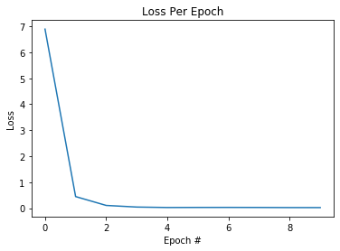

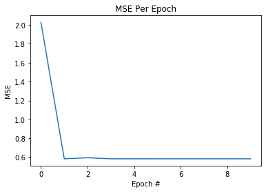

```python
sns.lineplot(x=np.array([x for x in range(EPOCH)]), y=np.array(TrainingLoss)) #Plot training loss per epoch
plt.title("Loss Per Epoch")
plt.xlabel("Epoch #")
plt.ylabel("Loss")
plt.show()
plt.clf()

sns.lineplot(x=np.array([x for x in range(EPOCH)]), y=np.array(TestingMSE)) #Plot MSE on testing set per epoch.
plt.title("MSE Per Epoch")
plt.xlabel("Epoch #")
plt.ylabel("MSE")
plt.show()
plt.clf()
```

The plots above show that the model overfit to the training data. The training loss decreased to 0, while the MSE on the test set plateaued. Unsurprisingly, the neural network model predicted 0 for all test samples. Due to the small sample size, the network is unable to precisely regress the correct output value. Throwing more data at this model will likely help it generalize better since the upvote ratio is a continuous variable.

```python
modelPerformance = []

for i, output in enumerate(zip(testOutput, predictedRatio)):
    target, prediction = output
    modelPerformance.append({"Example" : i, "True Ratio" : target , "Predicted Ratio" : prediction})

modelPerformance = pd.DataFrame(modelPerformance)
modelPerformance.head()
```

|  | Example | True Ratio | Predicted Ratio |
| --- | --- | --- | --- |
| 0 | 0 | 0.95 | 0 |
| 1 | 1 | 0.50 | 0 |
| 2 | 2 | 0.49 | 0 |
| 3 | 3 | 0.52 | 0 |
| 4 | 4 | 0.87 | 0 |

```python
trainInput, testInput, trainOutput, testOutput = train_test_split(inputClassificationData, outputClassificationData, test_size=0.1)
testOutput = [i[0] for i in testOutput]

class PredictRedditPost(nn.Module):
    def __init__(self):
        super(PredictRedditPost, self).__init__()
        self.linearClassifier = nn.Sequential(nn.Linear(353, 64), nn.Dropout(0.5), nn.ReLU(),
                                              nn.Linear(64, 16), nn.ReLU(),
                                              nn.Linear(16, 1))
        self.sigmoid = nn.Sigmoid()
        #Same neural network architecture as above, now new and improved with a sigmoid activation function
    def forward(self, featureVector):
        return self.sigmoid(self.linearClassifier(featureVector))
```

```python
LR = 1e-3 #Learning Rate
WEIGHTDECAY=0.0005 #L2 Penalty which forces smaller weights and simpler models.
EPOCH = 10 #Number of iterations through the entire dataset

device = torch.device("cuda:0" if torch.cuda.is_available() else "cpu")
model = PredictRedditPost()
model.to(device)
optimizer = optim.Adam(model.parameters(), lr=LR, weight_decay=WEIGHTDECAY)
BCEL = nn.BCELoss() #Binary Cross Entropy Loss used for two-class classifiation tasks

#Same training loop as regression case
TestingAccuracy = []
TrainingLoss = []
for STEP in range(1, EPOCH + 1):
    epochLoss = 0
    model.train()

    for batchCount, data in enumerate(zip(trainInput, trainOutput)):
        handCraftedFeatures, postType = data

        handCraftedFeatures = torch.tensor(handCraftedFeatures) #Formatting features to play nice with PyTorch
        postType = torch.tensor(postType)

        handCraftedFeatures = handCraftedFeatures.to(device) #Send to GPU
        postType = postType.to(device)

        predictedPostType = model(handCraftedFeatures)

        optimizer.zero_grad()
        Loss = BCEL(predictedPostType, postType)
        epochLoss = epochLoss + Loss.item()

        Loss.backward()
        optimizer.step()

    print("Epoch " + str(STEP) + " Loss: " + str(epochLoss / batchCount))
    TrainingLoss.append(epochLoss / batchCount)

    model.eval()
    testInput = torch.tensor(testInput)
    testInput = testInput.to(device)
    predictedPostType = torch.round(model(testInput))

    predictedPostType = [int(i[0]) for i in predictedPostType.tolist()]
    Accuracy = metrics.accuracy_score(testOutput, predictedPostType)
    print("Epoch "+ str(STEP) + " Accuracy: " + str(Accuracy) + "\n")
    TestingAccuracy.append(Accuracy)
```

```
Epoch 1 Loss: 0.7118885397991939
Epoch 1 Accuracy: 0.7415730337078652

Epoch 2 Loss: 0.6699189038024655
Epoch 2 Accuracy: 0.7415730337078652

Epoch 3 Loss: 0.5273262527662723
Epoch 3 Accuracy: 0.7415730337078652

Epoch 4 Loss: 0.5522850346295222
Epoch 4 Accuracy: 0.848314606741573

Epoch 5 Loss: 0.4636425507706569
Epoch 5 Accuracy: 0.8876404494382022

Epoch 6 Loss: 0.45011415637895086
Epoch 6 Accuracy: 0.8595505617977528

Epoch 7 Loss: 0.4067802755341643
Epoch 7 Accuracy: 0.9438202247191011

Epoch 8 Loss: 0.45339107194554745
Epoch 8 Accuracy: 0.8539325842696629

Epoch 9 Loss: 0.40663455717023383
Epoch 9 Accuracy: 0.949438202247191

Epoch 10 Loss: 0.35305965436353764
Epoch 10 Accuracy: 0.9438202247191011
```

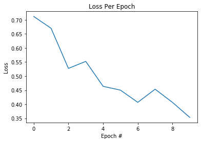

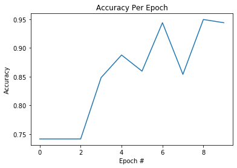

```python
sns.lineplot(x=np.array([x for x in range(EPOCH)]), y=np.array(TrainingLoss)) #Plot training loss per epoch
plt.title("Loss Per Epoch")
plt.xlabel("Epoch #")
plt.ylabel("Loss")
plt.show()
plt.clf()

sns.lineplot(x=np.array([x for x in range(EPOCH)]), y=np.array(TestingAccuracy)) #Plot classification accuracy per epoch
plt.title("Accuracy Per Epoch")
plt.xlabel("Epoch #")
plt.ylabel("Accuracy")
plt.show()
plt.clf()
```

The key takeaway from these experiments is that although many state-of-the-art methods use neural networks and deep learning, the size of the dataset plays an important role in whether to stick with traditional machine learning based approaches, or try deep learning models. Let's try to understand our features to see what really goes into making a great post.

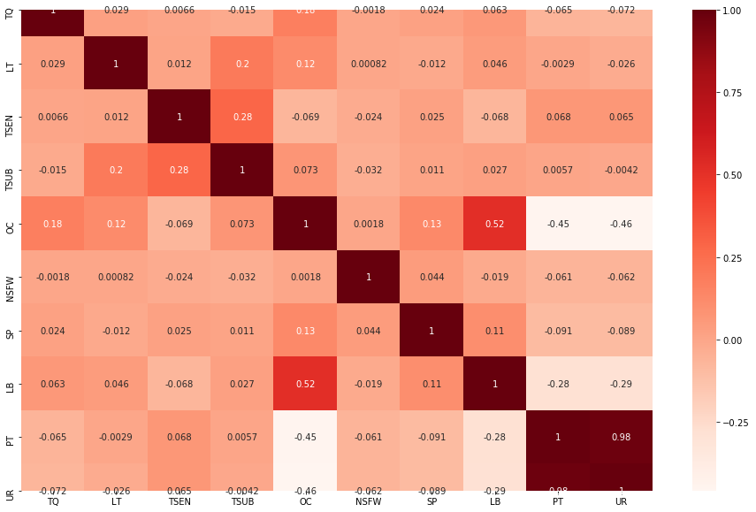

```python
numericalFeatureSelection = []

for tableRow in dataSet.iterrows():
    lenTitle = tableRow[1]["len_title"]
    titleSentiment = tableRow[1]["title_sentiment"]
    titleSubjectivity = tableRow[1]["title_subjectivity"]
    titleQuestion  =tableRow[1]["title_question"]
    originalContent = tableRow[1]["is_oc"]
    nsfw = tableRow[1]["is_nsfw"]
    spoiler = tableRow[1]["is_spoiler"]

    lenBody = tableRow[1]["len_body"]

    post_type = tableRow[1]["post_type"]
    upvote_ratio = tableRow[1]["upvote_ratio"]

    numericalFeatureSelection.append({"TQ": titleQuestion, "LT" : lenTitle, "TSEN" : titleSentiment, "TSUB" : titleSubjectivity,
                                      "OC" : originalContent, "NSFW" : nsfw, "SP" : spoiler,
                                      "LB" : lenBody, "PT" : post_type, "UR" : upvote_ratio})

featureSelection = pd.DataFrame(numericalFeatureSelection)
plt.figure(figsize=(16,10))
pearsonCorrelation = featureSelection.corr() #Pearsons correlatin coeff.
sns.heatmap(pearsonCorrelation, annot=True, cmap=plt.cm.Reds) # Seaborn makes nice plots
plt.show()
```

```python
#Look Up Table for Above Plot
pprint({"TQ": "Title Contains Question","LT" : "Length of Tilte", "TSEN" : "Title Sentiment", "TSUB" : "Title Subjectivity",
                                      "OC" : "Original Content", "NSFW" : "Not Safe for Work", "SP" : "Spoiler",
                                      "LB" : "Length of Body", "PT" : "Post Type", "UR" : "Upvote Ratio"})
```

```
{'LB': 'Length of Body',
 'LT': 'Length of Tilte',
 'NSFW': 'Not Safe for Work',
 'OC': 'Original Content',
 'PT': 'Post Type',
 'SP': 'Spoiler',
 'TQ': 'Title Contains Question',
 'TSEN': 'Title Sentiment',
 'TSUB': 'Title Subjectivity',
 'UR': 'Upvote Ratio'}
```

Throughout this tutorial, we have been trying to predict if a post will join the ranks of other top posts, or be condemned as a controvertial post. The correlation matrix above shows that almost none of the features we deemed to be important actually affected the results of our linear models. Interestingly, both the length post body and the use of original content negatively correlated with both the post type (PT) and upvote ratio (UR). In order to have a hot post, make sure to always repost material and never write well thought out content. Using this information, we can test our logistic regression model using only len_body and is_oc to predict post_type to see if we can get the same level of performance.

```python
inputClassificationData = []
outputClassificationData = []

for tableRow in dataSet.iterrows():
    originalContent = tableRow[1]["is_oc"]
    lenBody = tableRow[1]["len_body"]
    post_type = tableRow[1]["post_type"]

    inputClassificationData.append([lenBody, originalContent])
    outputClassificationData.append([post_type])

trainInput, testInput, trainOutput, testOutput = train_test_split(inputClassificationData, outputClassificationData, test_size=0.1)
ratioRegression = LogisticRegression().fit(np.array(trainInput), np.array(trainOutput))
predictedOutput = ratioRegression.predict(np.array(testInput))
modelPerformance = []

testOutput = [i[0] for i in testOutput]
predictedOutput = predictedOutput.tolist()

Accuracy = metrics.accuracy_score(testOutput, predictedOutput)
print("Accuracy: " + str(Accuracy))
```

```
Accuracy: 0.7303370786516854
```

Although our logistic regression predictor is able to acheive "better than random" accuracy, the performance is still much lower than when we included other features. A noteable feature that we are missing is the subreddit itself.

```python
inputClassificationData = []
outputClassificationData = []

for tableRow in dataSet.iterrows():
    subReddit = tableRow[1]["subreddit"]
    SR_oneHotEncoding = subRedditOneHotEncoding["subReddit_" + subReddit].to_list()
    originalContent = tableRow[1]["is_oc"]
    lenBody = tableRow[1]["len_body"]
    post_type = tableRow[1]["post_type"]

    inputClassificationData.append(SR_oneHotEncoding + [lenBody, originalContent])
    outputClassificationData.append([post_type])

trainInput, testInput, trainOutput, testOutput = train_test_split(inputClassificationData, outputClassificationData, test_size=0.1)
ratioRegression = LogisticRegression().fit(np.array(trainInput), np.array(trainOutput))
predictedOutput = ratioRegression.predict(np.array(testInput))
modelPerformance = []

testOutput = [i[0] for i in testOutput]
predictedOutput = predictedOutput.tolist()

Accuracy = metrics.accuracy_score(testOutput, predictedOutput)
print("Accuracy: " + str(Accuracy))
```

```
Accuracy: 0.9101123595505618
```

As suspected, the subreddit that you post in significantly impacts the likelihood of going viral on Reddit.